# Pathway analysis with QuSAGE: Single dataset

J. Taroni for ALSF CCDL

2019

## Background

In this module, we’ll demonstrate how to perform pathway analysis using Quantitative Set Analysis of Gene Expression (QuSAGE) ([Yaari et al. *NAR*. 2013.](https://doi.org/10.1093/nar/gkt660)). QuSAGE, implemented in the [`qusage` bioconductor package](https://bioconductor.org/packages/release/bioc/html/qusage.html), has some nice features:

- It takes into account inter-gene correlation (a source of type I error).
- It returns more information than just a p-value. That’s useful for analyses you might want to perform downstream.
- Built-in visualization functionality.

We recommend taking a look at the original publication (Yaari et al.) and the R package documentation to learn more.

## Gene sets

`qusage` allows you to read in gene sets that are in the [GMT format](http://software.broadinstitute.org/cancer/software/gsea/wiki/index.php/Data_formats#GMT:_Gene_Matrix_Transposed_file_format_.28.2A.gmt.29). [Curated gene sets from MSigDB](http://software.broadinstitute.org/gsea/msigdb/collections.jsp#C2) like [KEGG](https://www.genome.jp/kegg/) are popular for pathway analysis, but MSigDB only distributes human pathway data. Here, we’ll work with a mouse dataset.

In the `kegg_ortholog_mapping` notebook in this module, we mapped human Entrez IDs to mouse symbols using the [`hcop` package](https://github.com/stephenturner/hcop). When there was a 1:many mapping between human Entrez IDs and mouse gene symbols, we selected the mouse gene symbol with the highest number of resources supporting the mapping. This decision might not be suitable for every experiment and may result in some loss of information.

## Dataset

We’re using [`GSE75574`](https://www.refine.bio/experiments/GSE75574/gene-expression-in-mouse-tissues-in-response-to-short-term-calorie-restriction) in this notebook. This dataset assays the gene expression response to short-term calorie restriction in multiple tissues from multiple mouse strains. We’ll test for pathways that change in response to short-term calorie restriction.

## Set up

Package installation and loading

```r
if (!("qusage" %in% installed.packages())) {
  BiocManager::install("qusage", update = FALSE)
}

if (!("org.Mm.eg.db" %in% installed.packages())) {
  BiocManager::install("org.Mm.eg.db", update = FALSE)
}

if (!("pheatmap" %in% installed.packages())) {
  install.packages("pheatmap")
}
```

```r
`%>%` <- dplyr::`%>%`
```

```r
library(qusage)
library(org.Mm.eg.db)
library(pheatmap)
```

Create directories to hold plots and results if they do not yet exist.

```r
# Define the file path to the plots directory
plots_dir <- "plots"  # Replace with path to desired output plots directory

# Make a plots directory if it isn't created yet
if (!dir.exists(plots_dir)) {
  dir.create(plots_dir)
}

# Define the file path to the results directory
results_dir <- "results"  # Replace with path to desired output results directory

# Make a results directory if it isn't created yet
if (!dir.exists(results_dir)) {
  dir.create(results_dir)
}

# Define the file path to the data directory
data_dir <- "data"
```

## Read in refine.bio data

The gene expression matrix of the dataset we’ll be working with is too large to be tracked with git without compression, so we need to unzip it if we have not already.

```r
# if the unzipped folder does not exist
if (!dir.exists(file.path(data_dir,
                          "GSE75574" # Replace with the name of your file without the .zip extension
                          ))) {
  compressed_file <- file.path(data_dir,
                               "GSE75574.zip" # Replace with the name of your zipped file
                               )
  unzip(compressed_file, exdir = data_dir)
}
```

### Expression data

```r
expression_file <- file.path(data_dir,
                             "GSE75574", # Replace with name of your unzipped folder
                             "GSE75574.tsv" # Replace with name of your expression file
                             )
exprs_df <- readr::read_tsv(expression_file, progress = FALSE)
# first column is currently named 'Gene' and contains Ensembl gene IDs
colnames(exprs_df)[1] <- "ENSEMBL"
```

Because our gene sets use gene symbols and expression data from refine.bio uses Ensembl IDs, we need to do a conversion. We’re using the default behavior for 1:many mappings here, where only the first one is selected ([docs](https://www.rdocumentation.org/packages/AnnotationDbi/versions/1.30.1/topics/AnnotationDb-objects)).

```r
symbol_mappings <- mapIds(org.Mm.eg.db, keys = exprs_df$ENSEMBL,
                          column = "SYMBOL", keytype = "ENSEMBL")
```

```r
head(symbol_mappings)
```

```
ENSMUSG00000000001 ENSMUSG00000000003 ENSMUSG00000000028 ENSMUSG00000000031
           "Gnai3"             "Pbsn"            "Cdc45"              "H19"
ENSMUSG00000000037 ENSMUSG00000000049
           "Scml2"             "Apoh"
```

```r
# mapIds returns this in the same order as the keys we passed it to, let's
# demonstrate that
all.equal(names(symbol_mappings), exprs_df$ENSEMBL)
```

```
[1] TRUE
```

We’ll annotate these expression data with the gene symbols.

```r
symbol_exprs_df <- exprs_df %>%
  # add a new column that contains the gene symbols
  # this gets added as the last column
  dplyr::mutate(SYMBOL = symbol_mappings) %>%
  # drop the Ensembl gene IDs
  dplyr::select(-ENSEMBL) %>%
  # reorder such that the gene symbols are in the first column
  dplyr::select(SYMBOL, dplyr::everything()) %>%
  # drop any genes without a gene symbol
  dplyr::filter(!is.na(SYMBOL))
```

How many gene symbols have duplicate values?

```r
sum(duplicated(symbol_exprs_df$SYMBOL))
```

```
[1] 3
```

Collapse to the mean value for that gene symbol.

```r
symbol_exprs_df <- symbol_exprs_df %>%
  dplyr::group_by(SYMBOL) %>%
  dplyr::summarise_all(mean)
```

Write to file.

```r
readr::write_tsv(symbol_exprs_df, file.path(data_dir,
                                            "GSE75574", # Replace with name of your unzipped folder
                                            "GSE75574_symbols.tsv" # Replace with relevant output name
                                            ))
```

### Metadata

```r
metadata_file <- file.path(data_dir,
                           "GSE75574", # Replace with name of your unzipped folder
                           "metadata_GSE75574.tsv" # Replace with name of relevant metadata file
                           )
metadata_df <- readr::read_tsv(metadata_file) %>%
  # drop any metadata columns that are all NAs
  dplyr::select(-which(apply(is.na(.), 2, all)))
```

Retain only the most pertinent columns.

```r
metadata_df <- metadata_df %>%
  dplyr::select(refinebio_accession_code, refinebio_title,
                refinebio_specimen_part, refinebio_sex, strain)
```

This particular accession ([`GSE75574`](https://www.refine.bio/experiments/GSE75574/gene-expression-in-mouse-tissues-in-response-to-short-term-calorie-restriction)) is a SuperSeries comprised of experiments in multiple tissues from multiple mouse strains. We’ll use white adipose tissue for all strains in this example.

```r
metadata_df <- metadata_df %>%
  dplyr::filter(refinebio_specimen_part == "white adipose")
```

The two groups we are interested in for comparison are calorie restricted vs. controls. This information is in the title. We can extract this and put it in its own column called `condition`.

```r
metadata_df <- metadata_df %>%
  dplyr::mutate(condition = dplyr::case_when(
    grepl("control", refinebio_title) ~ "control",
    grepl("calorierestricted", refinebio_title) ~ "calorierestricted"
  ))
```

## Pathway Analysis

### Read in KEGG pathways

First, we need the sets of genes that represent pathways. Again, these were prepared in the `kegg_ortholog_mapping` notebook (see Gene Sets above).

```r
kegg_file <- file.path("gene-sets",
                       "c2.cp.kegg.v6.2.entrez_mouse_symbol_hcop.gmt")
kegg_pathways <- read.gmt(kegg_file)
```

### Prep expression matrix

```r
exprs_mat <- symbol_exprs_df %>%
  tibble::column_to_rownames("SYMBOL") %>%
  # same order as the metdata
  dplyr::select(metadata_df$refinebio_accession_code) %>%
  # qusage takes a matrix
  as.matrix()
```

We want to compare calorie restricted mice to controls.

```r
qusage_results <- qusage(eset = exprs_mat,
                         labels = metadata_df$condition,
                         contrast = "calorierestricted-control",
                         geneSets = kegg_pathways)
```

```
Aggregating gene data for gene sets......................................Done.
Calculating variance inflation factors...Done.
```

Save the `QSArray` output. We can use this object for visualization or other downstream analyses.

```r
readr::write_rds(qusage_results,
                 file.path(results_dir,
                           "GSE75574_adipose_calorierest-ctrl_QSarray.RDS" # Replace with file name relevant to output results
                           ))
```

### Overall results

We can get a look at the general trend of the results with the `plotCIs` function. This plots the means and 95% confidence intervals of each pathway we tested, sorted such that the gene sets with the highest mean will be on the left of the plot. These are gene sets that are elevated in calorie restricted mice. Error bars are colored by the directionality and corrected p-value (FDR by default). Unfortunately the p-value color scheme is red-green, which does not work well for people with green or red color-vision deficiency.

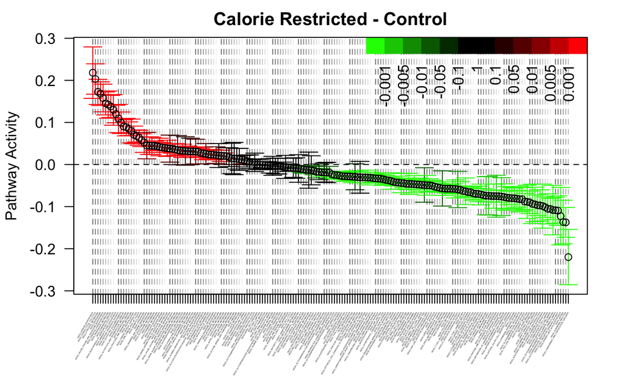

```r
plotCIs(qusage_results, cex.xaxis = 0.25, main = "Calorie Restricted - Control")
```

Save to plot.

```r
pdf(file.path("plots",
              "GSE75574_adipose_calorierestricted-control_plotCIs.pdf"),
    width = 14, height = 8.5)
plotCIs(qusage_results, cex.xaxis = 0.25, main = "Calorie Restricted - Control")
dev.off()
```

We can also look at the log fold-change and FDR values for pathways with the `qsTable` function. By default, this function shows you the top 20 pathways sorted by FDR. We can change the `number` argument to `qsTable` to decrease or increase the number of pathways returned. We can use the `numPathways` function to get *all* the pathways we tested.

```r
qsTable(qusage_results, number = numPathways(qusage_results))
```

|  | pathway.name | log.fold.change | p.Value | FDR |
| --- | --- | --- | --- | --- |
| 161 | KEGG_LEISHMANIA_INFECTION | -0.1372317945 | 0.000000e+00 | 0.000000e+00 |
| 49 | KEGG_GLYCOSPHINGOLIPID_BIOSYNTHESIS_GLOBO_SERIES | -0.1054669717 | 0.000000e+00 | 0.000000e+00 |
| 114 | KEGG_ECM_RECEPTOR_INTERACTION | -0.1013368124 | 0.000000e+00 | 0.000000e+00 |
| 132 | KEGG_FC_GAMMA_R_MEDIATED_PHAGOCYTOSIS | -0.0968694737 | 0.000000e+00 | 0.000000e+00 |
| 122 | KEGG_TOLL_LIKE_RECEPTOR_SIGNALING_PATHWAY | -0.0878086040 | 0.000000e+00 | 0.000000e+00 |
| 90 | KEGG_CHEMOKINE_SIGNALING_PATHWAY | -0.0811104987 | 0.000000e+00 | 0.000000e+00 |
| 113 | KEGG_FOCAL_ADHESION | -0.0793361915 | 0.000000e+00 | 0.000000e+00 |
| 95 | KEGG_P53_SIGNALING_PATHWAY | -0.0753177336 | 0.000000e+00 | 0.000000e+00 |
| 172 | KEGG_BLADDER_CANCER | -0.0748147669 | 0.000000e+00 | 0.000000e+00 |
| 110 | KEGG_TGF_BETA_SIGNALING_PATHWAY | -0.0728445534 | 0.000000e+00 | 0.000000e+00 |

[output cut: 176 more lines]

Write to results.

```r
qsTable(qusage_results, number = numPathways(qusage_results)) %>%
  readr::write_tsv(file.path(results_dir,
                             "GSE75574_adipose_calorierestricted-control.tsv" # Replace with file name relevant to results output
                             ))
```

`qusage` has functionality that lets us dig into our results a bit more to get an idea of which genes are contributing to the differences between our two groups.

### KEGG ECM Receptor Interaction

The KEGG ECM Receptor Interation pathway expression is reduced in response to calorie restriction.

We can look at the distribution of genes in this pathway with the `plotGeneSetDistributions` function. We tell this function which pathway to plot with the `path.index` argument.

```r
grep("ECM_RECEPTOR", # Replace with desired pathway -- names of pathways can be seen using the `names(kegg_pathways)` function
     names(kegg_pathways))
```

```
[1] 114
```

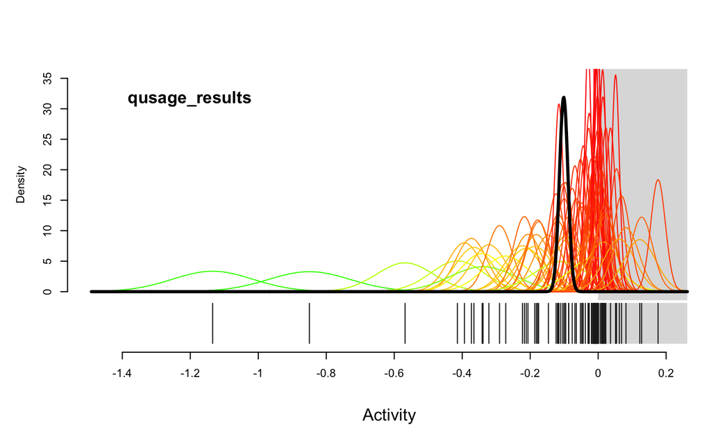

```r
plotGeneSetDistributions(qusage_results, path.index = 114)
```

*Most* genes are around zero (no activity), but we see some genes with negative activity values. We can dig into the *what* the genes are with the `plotCIsGenes` function.

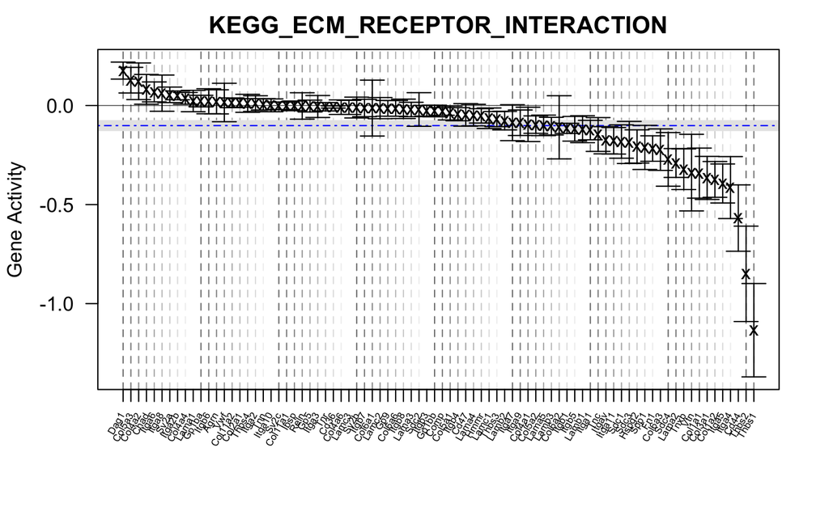

```r
plotCIsGenes(qusage_results, path.index = 114)
```

Let’s look at another example with the opposite directionality.

### KEGG Steroid Biosynthesis

The KEGG Steroid Biosynthesis pathway expression is increased in calorie restricted adipose tissue.

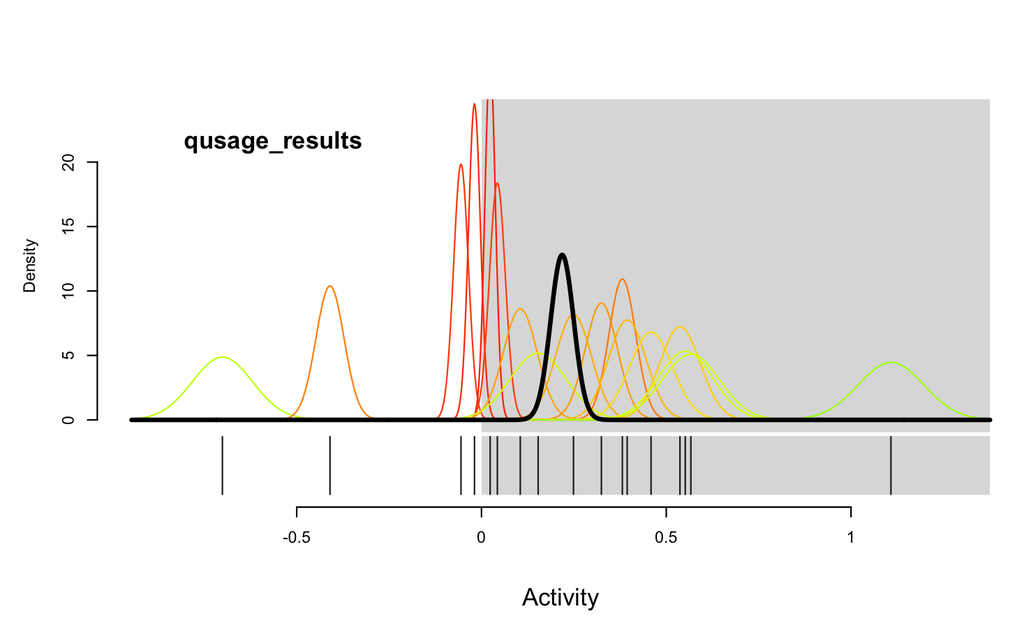

```r
plotGeneSetDistributions(qusage_results, path.index = 9)
```

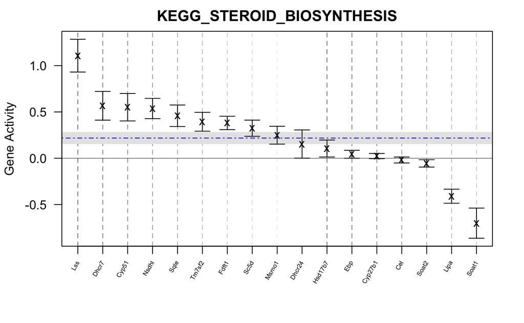

```r
plotCIsGenes(qusage_results, path.index = 9)
```

We can make a heatmap with only genes from this pathway. The heatmap will have similar information as `plotCIsGenes`, but we’ll also get a sense of how samples relate to one another.

#### Heatmap

Subset the expression matrix to only genes in the KEGG Steroid Biosynthesis pathways.

```r
steroid_genes <- kegg_pathways$KEGG_STEROID_BIOSYNTHESIS
# rows (genes) in the pathway
steroid_mat <- exprs_mat[which(rownames(exprs_mat) %in% steroid_genes), ]
```

We’ll use annotation bars for the columns (samples).

```r
# need a data.frame that contains the sample metadata that we're interested in
annotation_col_df <- metadata_df %>%
  dplyr::select(refinebio_accession_code, condition, strain) %>%
  tibble::column_to_rownames("refinebio_accession_code")

# colors to be used in the annotation bars -- we need to assign one for
# each factor level in the two columns
annot_colors <- list(
  condition = c(control = "#FFFFFF",
                calorierestricted = "#CD2626"),
  # palette from
  # https://github.com/clauswilke/colorblindr/blob/1ac3d4d62dad047b68bb66c06cee927a4517d678/R/palettes.R#L7
  strain = c(`129S1/SvImJ` = "#E69F00",
             `B6C3F1/J` = "#56B4E9",
             `Balbc/J` = "#009E73",
             `C3H/HeJ` = "#F0E442",
             `C57BL6/J` = "#0072B2",
             `CBA/J` = "#D55E00",
             `DBA/2J` = "#CC79A7")
)
```

Let’s make the heatmap with annotation bars.

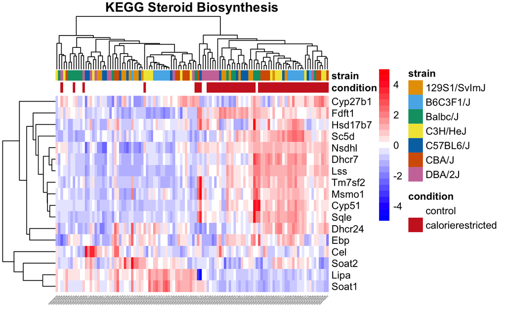

```r
hm_plot <- pheatmap::pheatmap(steroid_mat,
                              # using blue, white, red color scheme
                              color = colorRampPalette(c("#0000FF", "#FFFFFF",
                                                         "#FF0000"))(25),
                              clustering_distance_cols = "correlation",
                              clustering_distance_rows = "correlation",
                              clustering_method = "average",
                              # scale the expression values of genes for
                              # visualization
                              scale = "row",
                              fontsize_col = 2,
                              angle_col = "45",
                              annotation_col = annotation_col_df,
                              annotation_colors = annot_colors,
                              main = "KEGG Steroid Biosynthesis")
```

Save the plot.

```r
pdf(file.path(plots_dir,
              "GSE75574_steroid_biosynthesis_heatmap.pdf" # Replace with relevant output plot name
              ),
    width = 7, height = 5)
print(hm_plot)
dev.off()
```